# Carga de datos y programación básica en R

Felipe Calvo Cepeda - fcalvoc@unal.edu.co | Universidad Nacional de Colombia

2023

## Importar datos a R

- Conjunto de datos

> Una vez descargados los archivos de datos, vamos a ubicarlos al interior de una carpeta llamada **data** que a su vez crearemos dentro del directorio de nuestro proyecto.

### Paquetes para importar datos

```r
# Instalamos los paquetes
install.packages("tidyverse", dependencies=TRUE, INSTALL_opts = c("--no-multiarch"))
install.packages("readxl")
install.packages("haven")
install.packages("googlesheets4")
install.packages("DBI")
install.packages("RMySQL")

# Cargamos los paquetes
library("tidyverse")
library("readxl")
library("haven")
library("googlesheets4")
library("DBI")
library("RMySQL")
```

### Archivos de texto plano (.txt)

```r
read_delim(
  file = "data/Boston_Housing.txt",
  delim = "|",
  locale=locale(decimal_mark = ",")
  ) -> boston_housing_txt

read.table(
  file =  "data/Boston_Housing.txt",
  sep =  "|",
  header = TRUE,
  dec = ",",
  fileEncoding = "UTF-8"
  ) -> boston_housing_txt

str(boston_housing_txt)
```

### Archivo de valores separados por comas (.csv)

```r
read_csv2(
  file = "data/Boston_Housing.csv"
) -> boston_housing_csv

str(boston_housing_csv)
```

### Archivos de Excel (.xls .xlsx)

```r
## library("readxl")
read_excel(
  path = "data/Boston_Housing.xls"
) -> boston_housing_xls

str(boston_housing_xls)

read_xlsx(
  path = "data/Boston_Housing.xlsx",
  sheet="Data"
) -> boston_housing_xlsx

str(boston_housing_xlsx)
```

### Archivos de STATA (.dta)

```r
## library("haven")
read_dta(
  file = "data/Boston_Housing.dta"
) -> boston_housing_dta

str(boston_housing_dta)
```

### Archivos de bases de datos de SPSS

```r
## library("haven")
read_sav(
  file = "data/PRICING.sav"
) -> pricing_sav

str(pricing_sav)
```

### Hojas de cálculo en Google Sheets

Podemos leer desde R hojas de cálculo públicas o privadas.

- Hojas públicas

```r
# library("googlesheets4")
# Comando para que no nos exija autenticación
gs4_deauth()
# Declaro el enlace
link = "https://docs.google.com/spreadsheets/d/1z7uEedjNKXN4ub5lNZLO-dJhtWs4-Lv3PRcOTf-HWdk/edit?usp=sharing"
# Lectura de datos
boston_housing_gs <- read_sheet(link)

str(boston_housing_gs)
```

- Hojas privadas

```r
# library("googlesheets4")
# Comando para validar autenticación
gs4_auth()
# Declaro el enlace
link = "https://docs.google.com/spreadsheets/d/1z7uEedjNKXN4ub5lNZLO-dJhtWs4-Lv3PRcOTf-HWdk/edit?usp=sharing"
# Lectura de datos
boston_housing_gs <- read_sheet(link)

str(boston_housing_gs)
```

## Usando la interfaz de RStudio

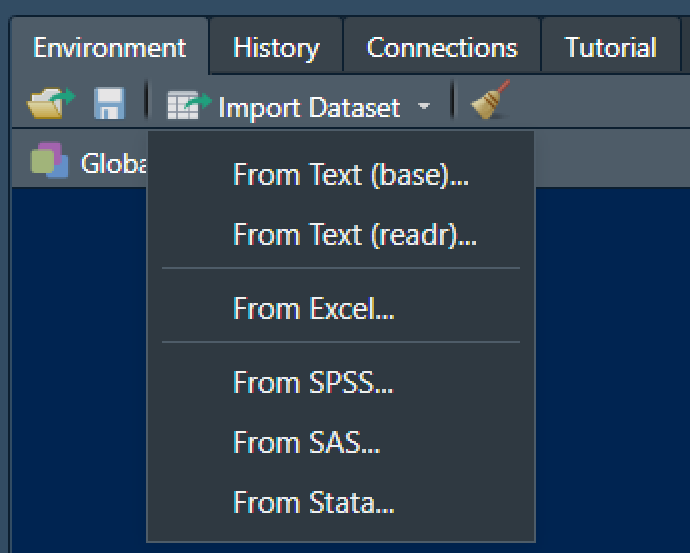

> Ya sabemos importar datos.

> Ahora vamos a ver distintos elementos que necesitamos para procesarlos.

## Algoritmos

Un algoritmo es un conjunto finito de instrucciones que, si se siguen rigurosamente, llevan a cabo una tarea específica.

Todos los algoritmos se componen de “partes” básicas que se utilizan para crear “partes” más complejas.

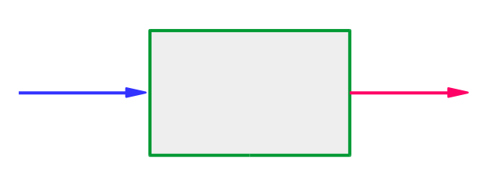

> El **tratamiento, análisis y modelado de datos** lo haremos mediante algoritmos.

## Variables y datos

- **Variables**: característica observable o un aspecto discernible en un objeto de estudio, que puede adoptar diferentes valores o expresarse en varias categorías.
- **Dato**: realización, representación o valor observado de una variable.

## Tipos de variables y operaciones

### Enfoque teórico

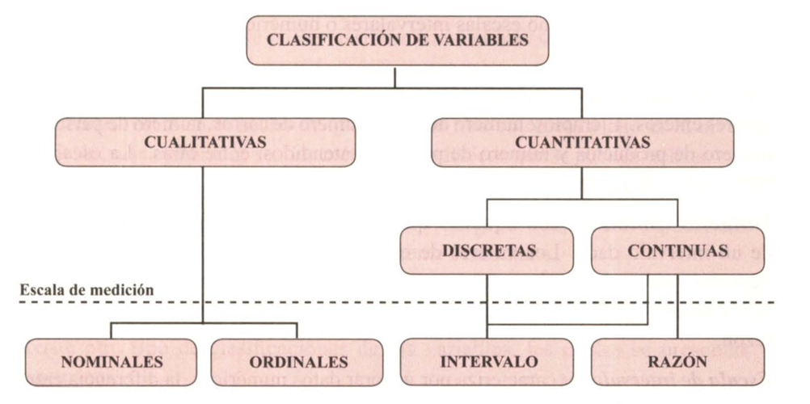

### Enfoque desde la programación

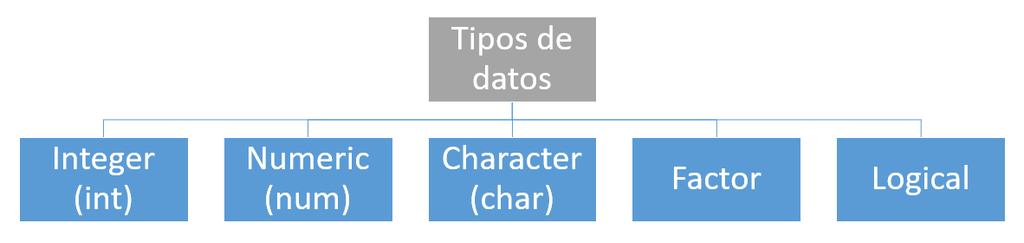

### Asignación

```r
# Una forma de hacer asignación
objeto = "valor"
# Otra forma
objeto <- "valor"
# Ejemplos
pais = "Colombia"
departamentos = 32
tenemos_mar = TRUE
```

### Tipos de variables

- Booleanos (lógicos)
  - VERDADERO
  - FALSO

```r
objeto_nombrado_por_mi <- TRUE # Siempre con mayúsculas
objeto_nombrado_por_mi
```

```
## [1] TRUE
```

```r
class(objeto_nombrado_por_mi)
```

```
## [1] "logical"
```

```r
is.logical(objeto_nombrado_por_mi)
```

```
## [1] TRUE
```

- Numéricos
  - Enteros
  - Reales

```r
pi
```

```
## [1] 3.141593
```

```r
objeto_nombrado_por_mi <- 0
objeto_nombrado_por_mi
```

```
## [1] 0
```

```r
class(objeto_nombrado_por_mi)
```

```
## [1] "numeric"
```

```r
is.numeric(objeto_nombrado_por_mi)
```

```
## [1] TRUE
```

- Alfanuméricos: caracteres o cadenas de texto

```r
objeto_nombrado_por_mi <- "hola mundo"
objeto_nombrado_por_mi
```

```
## [1] "hola mundo"
```

```r
class(objeto_nombrado_por_mi)
```

```
## [1] "character"
```

```r
is.character(objeto_nombrado_por_mi)
```

```
## [1] TRUE
```

- Fechas

```r
objeto_nombrado_por_mi <- "2022-03-24" # Recomendado: ISO 8601 para fechas
objeto_nombrado_por_mi
```

```
## [1] "2022-03-24"
```

```r
class(objeto_nombrado_por_mi)
```

```
## [1] "character"
```

```r
otro_objeto_distinto <- as.Date(objeto_nombrado_por_mi)
class(otro_objeto_distinto)
```

```
## [1] "Date"
```

- NA

```r
objeto_nombrado_por_mi <- NA # Siempre en mayúsculas NA
objeto_nombrado_por_mi
```

```
## [1] NA
```

```r
class(objeto_nombrado_por_mi)
```

```
## [1] "logical"
```

### Método **is**

```r
cualquier_cosa <- TRUE
is.logical(cualquier_cosa)
```

```
## [1] TRUE
```

```r
is.numeric(cualquier_cosa)
```

```
## [1] FALSE
```

```r
is.character(cualquier_cosa)
```

```
## [1] FALSE
```

### Método **as**

```r
TRUE -> true_logico
true_logico
```

```
## [1] TRUE
```

```r
class(true_logico)
```

```
## [1] "logical"
```

```r
as.character(true_logico) -> true_char
true_char
```

```
## [1] "TRUE"
```

```r
class(true_char)
```

```
## [1] "character"
```

```r
1 -> uno_numeric
uno_numeric
```

```
## [1] 1
```

```r
class(uno_numeric)
```

```
## [1] "numeric"
```

```r
as.character(uno_numeric) -> uno_char
uno_char
```

```
## [1] "1"
```

```r
class(uno_char)
```

```
## [1] "character"
```

### Conversiones

| Desde | Hacia |
| --- | --- |
| logical | numeric |
| logical | character |
| numeric | character |
| numeric | Date |
| character | Date |

### Operadores matemáticos

```r
2+2
```

```
## [1] 4
```

```r
5-2
```

```
## [1] 3
```

```r
3*4
```

```
## [1] 12
```

```r
5/4
```

```
## [1] 1.25
```

```r
9 %% 2
```

```
## [1] 1
```

```r
3 ** 3
```

```
## [1] 27
```

```r
3 ^ 3
```

```
## [1] 27
```

```r
log(10)
```

```
## [1] 2.302585
```

```r
sqrt(16)
```

```
## [1] 4
```

### Operadores para comparación

```r
5 > 2
```

```
## [1] TRUE
```

```r
5 < 2
```

```
## [1] FALSE
```

```r
10 == 10
```

```
## [1] TRUE
```

```r
10 == 9
```

```
## [1] FALSE
```

```r
10 != 9
```

```
## [1] TRUE
```

```r
10 >= 10
```

```
## [1] TRUE
```

```r
10 <= 8
```

```
## [1] FALSE
```

### Operadores lógicos

- Conjunción (se cumplen ambas): &&
- Disyunción (se cumple alguna): ||
- Negación (lo contrario): !

### Orden de las operaciones

- PEMDAS
  - Paréntesis
  - Exponentes
  - Multiplicaciones / Divisiones
  - Adición / Sustracción

## Variables

```r
pi = 3.1415
radio = 3
area = pi * radio**2
area
```

```
## [1] 28.2735
```

```r
round(area, 2)
```

```
## [1] 28.27
```

## Vectores, matrices, arreglos, listas y tablas

- Vectores: Arreglos lineales del mismo tipo. Tienen la misma clase.
- Matrices: Arreglos rectangulares del mismo tipo. Sábanas de la misma clase.
- Arreglos: Organizaciones cúbicas y de mayor dimensión.
- Listas: Arreglos lineales de distintos tipos.
- Tablas: La estructura data.frame permite tener tablas de datos, donde cada columna es de un tipo determinado, pero no todas iguales.

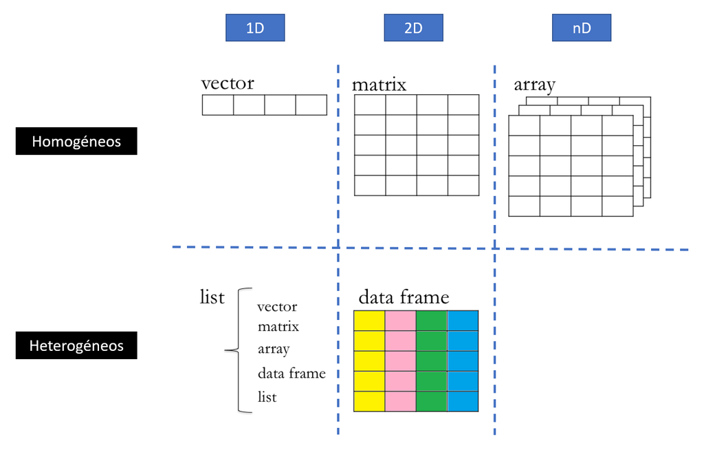

## Un tipo especial de variables: factores

Son vectores numéricos enmascarados como caracteres. Se usan para crear grupos usando clasificaciones o codificaciones de las variables de interés. Estos factores pueden o no tener un orden.

Ejemplos: estrato socioeconómico, nivel de estudios, mes, sexo, localidad.

### Vectores

```r
1:5
```

```
## [1] 1 2 3 4 5
```

```r
letters
```

```
##  [1] "a" "b" "c" "d" "e" "f" "g" "h" "i" "j" "k" "l" "m" "n" "o" "p" "q" "r" "s"
## [20] "t" "u" "v" "w" "x" "y" "z"
```

```r
LETTERS
```

```
##  [1] "A" "B" "C" "D" "E" "F" "G" "H" "I" "J" "K" "L" "M" "N" "O" "P" "Q" "R" "S"
## [20] "T" "U" "V" "W" "X" "Y" "Z"
```

```r
c(1, 3, 2, 15, 4, 0, 0, 0, 1)
```

```
## [1]  1  3  2 15  4  0  0  0  1
```

```r
seq(10, 100)
```

```
##  [1]  10  11  12  13  14  15  16  17  18  19  20  21  22  23  24  25  26  27  28
## [20]  29  30  31  32  33  34  35  36  37  38  39  40  41  42  43  44  45  46  47
## [39]  48  49  50  51  52  53  54  55  56  57  58  59  60  61  62  63  64  65  66
## [58]  67  68  69  70  71  72  73  74  75  76  77  78  79  80  81  82  83  84  85
## [77]  86  87  88  89  90  91  92  93  94  95  96  97  98  99 100
```

```r
seq(10, 100, by = 5)
```

```
##  [1]  10  15  20  25  30  35  40  45  50  55  60  65  70  75  80  85  90  95 100
```

```r
seq(10, 100, length.out = 8)
```

```
## [1]  10.00000  22.85714  35.71429  48.57143  61.42857  74.28571  87.14286
## [8] 100.00000
```

### Factores

```r
as.factor(letters)
```

```
##  [1] a b c d e f g h i j k l m n o p q r s t u v w x y z
## Levels: a b c d e f g h i j k l m n o p q r s t u v w x y z
```

### Funciones sobre vectores

```r
vector_logico <- c(TRUE,FALSE,FALSE,TRUE,FALSE)
vector_cualquiera <- seq(1, 100, by = 3)
un_vector <- c(1, 2, 3, 4, 5)
otro_vector <- c(6, 7, 8, 9, 10)
```

```r
which(vector_logico) # me dice cuales son los verdaderos
```

```
## [1] 1 4
```

```r
length(vector_cualquiera) # me dice cuánto mide el vector
```

```
## [1] 34
```

```r
c(un_vector, otro_vector) # concatena los vectores
```

```
##  [1]  1  2  3  4  5  6  7  8  9 10
```

### Operaciones entre vectores

```r
vector_numerico <- c(2, 4, 6, 8, 10)
vector_numeric_1 <- 1:3
vector_numeric_2 <- 3:5
```

```r
vector_numerico > 3
```

```
## [1] FALSE  TRUE  TRUE  TRUE  TRUE
```

```r
1:5 %in% 3:8
```

```
## [1] FALSE FALSE  TRUE  TRUE  TRUE
```

```r
outer(vector_numeric_1, vector_numeric_2, "*")
```

```
##      [,1] [,2] [,3]
## [1,]    3    4    5
## [2,]    6    8   10
## [3,]    9   12   15
```

```r
outer(vector_numeric_1, vector_numeric_2, ">")
```

```
##       [,1]  [,2]  [,3]
## [1,] FALSE FALSE FALSE
## [2,] FALSE FALSE FALSE
## [3,] FALSE FALSE FALSE
```

### Operaciones entre vectores (conjuntos)

```r
union(vector_numeric_1, vector_numeric_2)
```

```
## [1] 1 2 3 4 5
```

```r
intersect(vector_numeric_1, vector_numeric_2)
```

```
## [1] 3
```

```r
setdiff(vector_numeric_1, vector_numeric_2)
```

```
## [1] 1 2
```

### Matrices

```r
matrix(data = 1:12, nrow = 3)
```

```
##      [,1] [,2] [,3] [,4]
## [1,]    1    4    7   10
## [2,]    2    5    8   11
## [3,]    3    6    9   12
```

```r
matrix(data = 1:12, nrow = 6)
```

```
##      [,1] [,2]
## [1,]    1    7
## [2,]    2    8
## [3,]    3    9
## [4,]    4   10
## [5,]    5   11
## [6,]    6   12
```

```r
matrix(data = 1:12, ncol = 6)
```

```
##      [,1] [,2] [,3] [,4] [,5] [,6]
## [1,]    1    3    5    7    9   11
## [2,]    2    4    6    8   10   12
```

```r
matrix(data = 1:12, nrow = 4)
```

```
##      [,1] [,2] [,3]
## [1,]    1    5    9
## [2,]    2    6   10
## [3,]    3    7   11
## [4,]    4    8   12
```

```r
matrix(data = 1:12, nrow = 4, byrow = TRUE)
```

```
##      [,1] [,2] [,3]
## [1,]    1    2    3
## [2,]    4    5    6
## [3,]    7    8    9
## [4,]   10   11   12
```

```r
matrix(data = seq(0, 9, length.out = 4), nrow = 2) -> mi_matriz
mi_matriz
```

```
##      [,1] [,2]
## [1,]    0    6
## [2,]    3    9
```

### Operaciones sobre matrices

```r
otra_matriz # Toca inventársela
mi_matriz*2
mi_matriz + otra_matriz
mi_matriz*otra_matriz # Producto celda por celda
mi_matriz %*% otra_matriz # Producto de matrices
```

### Funciones sobre matrices

```r
t(mi_matriz) #mi_matriz transpuesta
```

```
##      [,1] [,2]
## [1,]    0    3
## [2,]    6    9
```

```r
diag(mi_matriz) #Diagonal de mi_matriz
```

```
## [1] 0 9
```

```r
det(mi_matriz) # Determinante, debe dar un número
```

```
## [1] -18
```

```r
solve(mi_matriz) # Matriz inversa, sólo se puede con matrices cuadradas de determinante distinto de cero
```

```
##            [,1]      [,2]
## [1,] -0.5000000 0.3333333
## [2,]  0.1666667 0.0000000
```

```r
dim(mi_matriz) # Dimensión de mi matriz
```

```
## [1] 2 2
```

> Bibliografía complementaria: [Capítulo 2: Linear Algebra, del libro Deep Learning del MIT](https://www.deeplearningbook.org/)

### Tablas

- [Tidy tables](https://www.jstatsoft.org/article/view/v059i10/v59i10.pdf)

```r
iris
diamonds
?diamonds
mpg
?mpg

class(diamonds)
class(mpg)

str(diamonds)
str(mpg)

View(diamonds)
View(mpg)
```